# Project Python Foundations: FoodHub Data Analysis

#### Delivery time

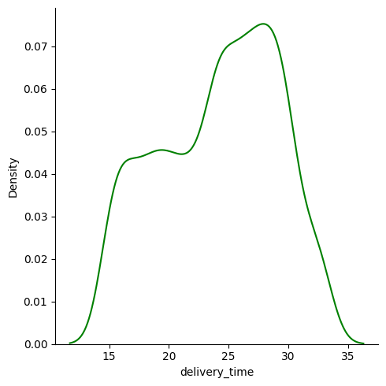

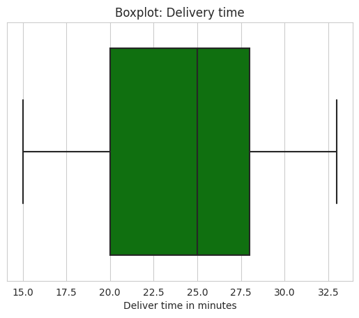

```python
# Delivery Time
sns.displot(data=df,x='delivery_time',kind='kde',color='green')
sns.set_style("whitegrid")
plt.show()
sns.boxplot(data=df,x='delivery_time',color='green')
plt.title('Boxplot: Delivery time')
plt.xlabel("Deliver time in minutes")
plt.show()
```

The distribution of the delivery time is slightly skewed to the left with no outlers.

#### Number of customers and Number of orders

```python
#Let check the number of customers and the number of orders
customer = df['customer_id'].nunique()
order = df['order_id'].nunique()
print("The number of customers is", customer, "while the number of orders is", order)
```

```
The number of customers is 1200 while the number of orders is 1898
```

#### Resturant name, Cuisine type, Day of the week, and Rating

```python
# Making a list of all categorical variables
cat_cols =  ['restaurant_name', 'cuisine_type', 'day_of_the_week', 'rating']

# Printing the count of unique categorical levels in each column
for column in cat_cols:
    print(df[column].value_counts())
    print(df[column].nunique())
    print("-" * 50)
```

```
Shake Shack                  219
The Meatball Shop            132
Blue Ribbon Sushi            119
Blue Ribbon Fried Chicken     96
Parm                          68
                            ...
Sushi Choshi                   1
Dos Caminos Soho               1
La Follia                      1
Philippe Chow                  1
'wichcraft                     1
Name: restaurant_name, Length: 178, dtype: int64
178
--------------------------------------------------
American          584
Japanese          470
Italian           298
Chinese           215
Mexican            77
Indian             73
Middle Eastern     49
Mediterranean      46
Thai               19
French             18
Southern           17
Korean             13
Spanish            12
Vietnamese          7
Name: cuisine_type, dtype: int64
14
--------------------------------------------------
Weekend    1351
Weekday     547
Name: day_of_the_week, dtype: int64
2
--------------------------------------------------
Not given    736
5            588
4            386
3            188
Name: rating, dtype: int64
4
--------------------------------------------------
```

.There are about 178 resturants from 14 different cuisine.

.There are about 1351 orders in the weekend and 547 in the weekday.

.The rating of the orders from 3 to 5.

#### Cuisine type

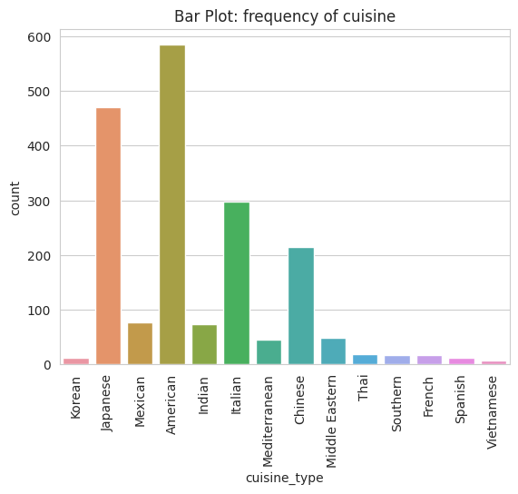

```python
#cusine type
sns.countplot(data=df,x='cuisine_type')
plt.title("Bar Plot: frequency of cuisine")
plt.xticks(rotation =90)
plt.show()
```

. There are about 14 different cuisine.

.The most popular is the American cuisine with more than 550 orders then the Japanese cuisine with about 500 orders.

#### Day of the week

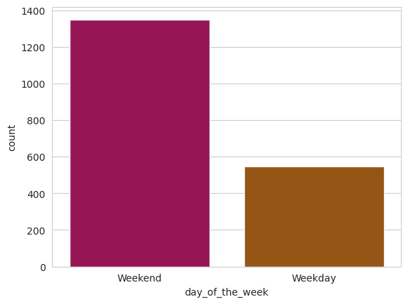

```python
sns.countplot(data=df,x='day_of_the_week',palette='brg')
plt.show()
```

The orders during the weekend are more than double the orders during the weekdays

#### Rating of orders

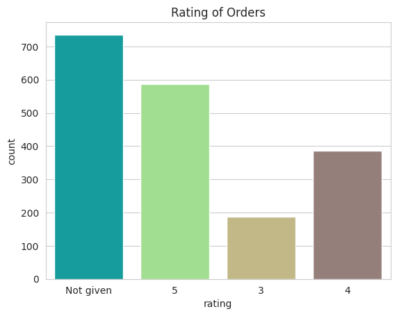

```python
sns.countplot(data=df,x='rating',palette='terrain')
plt.title("Rating of Orders")
plt.show()
```

.More than 700 orders did not get any rating.

. About 600 orders are rated 5.

.Rate 4 are given for 400 orders.

.The lest rate was 3 for about 200 orders.

### **Question 7**: Which are the top 5 restaurants in terms of the number of orders received? [1 mark]

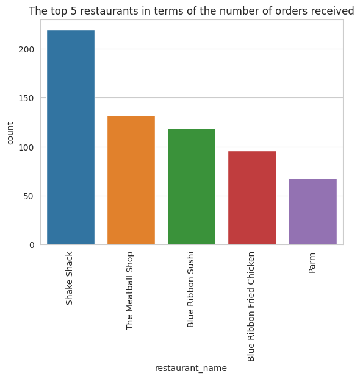

```python
sns.countplot(data=df,x='restaurant_name',order=pd.value_counts(df['restaurant_name']).iloc[:5].index)
plt.title("The top 5 restaurants in terms of the number of orders received")
plt.xticks(rotation=90)
plt.show()
```

#### Observations:

The top 5 restaurants in terms of the number of orders received:

1. Shake Shaack.
2. The Meatball Shop.
3. Blue Ribon Sushi.
4. Blue Ribon Fried Chicken.
5. Parm

### **Question 8**: Which is the most popular cuisine on weekends? [1 mark]

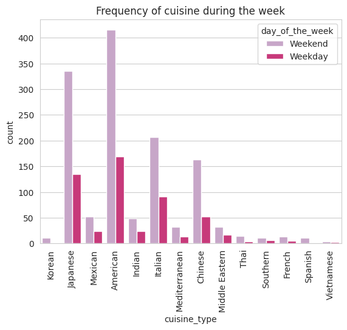

```python
sns.countplot(data=df,x='cuisine_type',hue='day_of_the_week',palette="PuRd")
plt.title("Frequency of cuisine during the week")
plt.xticks(rotation =90)
plt.show()
```

#### Observations:

The most popular cuisine on weekends is American cuisine.

### **Question 9**: What percentage of the orders cost more than 20 dollars? [2 marks]

```python
cost = df[df['cost_of_the_order'] > 20]
prcentage = (cost.shape[0]/df.shape[0])*100
print("The percentage of the orders cost more than 20 dollars:",'%.2f'%prcentage,"%")
```

```
The percentage of the orders cost more than 20 dollars: 29.24 %
```

#### Observations:

The percentage of the orders cost more than 20 dollars: 29.24 %

### **Question 10**: What is the mean order delivery time? [1 mark]

```python
df['delivery_time'].mean()
```

```
24.161749209694417
```

#### Observations:

The mean order delivery time is 24.16 min

### **Question 11:** The company has decided to give 20% discount vouchers to the top 3 most frequent customers. Find the IDs of these customers and the number of orders they placed. [1 mark]

```python
df['customer_id'].value_counts()
```

```
52832     13
47440     10
83287      9
250494     8
259341     7
          ..
385426     1
254913     1
289597     1
74412      1
397537     1
Name: customer_id, Length: 1200, dtype: int64
```

#### Observations:

The top 3 most frequent customers who will get 20% discount vouchers from the company: 52832, 47440, 83287

### **Question 12**: Perform a multivariate analysis to explore relationships between the important variables in the dataset. (It is a good idea to explore relations between numerical variables as well as relations between numerical and categorical variables) [10 marks]

#### The correlation coefficient between variables

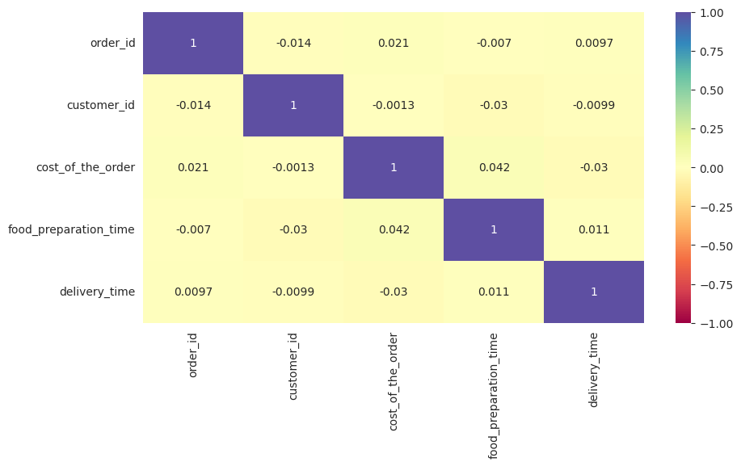

```python
#plot the heatmap
plt.figure(figsize=(10,5))
sns.heatmap(df.corr(),annot=True,cmap='Spectral',vmin=-1,vmax=1)
plt.show();
```

.Since all the cells with yellow color that means all the correlation cofficients are around 0 which indicate weak relationship.

.There is a weak negative relation between cost of the order and the delivery time, and weak positive relation between cost of the order and the food preparation time.

.There is a weak positive relation between the food preparation time and the delivary time.

.We should not consider the correlation value with custome id and order id because this columns are unique identifier for customer and order.

#### Total time(food preparation time + delivery time)

```python
# let's create a column total time with a sum of food preparation time, and delivery time
df['total_time'] = df['food_preparation_time'] + df['delivery_time']
df.head()
```

|  | order_id | customer_id | restaurant_name | cuisine_type | cost_of_the_order | day_of_the_week | rating | food_preparation_time | delivery_time | total_time |
| --- | --- | --- | --- | --- | --- | --- | --- | --- | --- | --- |
| 0 | 1477147 | 337525 | Hangawi | Korean | 30.750 | Weekend | Not given | 25 | 20 | 45 |
| 1 | 1477685 | 358141 | Blue Ribbon Sushi Izakaya | Japanese | 12.080 | Weekend | Not given | 25 | 23 | 48 |
| 2 | 1477070 | 66393 | Cafe Habana | Mexican | 12.230 | Weekday | 5 | 23 | 28 | 51 |
| 3 | 1477334 | 106968 | Blue Ribbon Fried Chicken | American | 29.200 | Weekend | 3 | 25 | 15 | 40 |
| 4 | 1478249 | 76942 | Dirty Bird to Go | American | 11.590 | Weekday | 4 | 25 | 24 | 49 |

#### Total time and Cost of the order

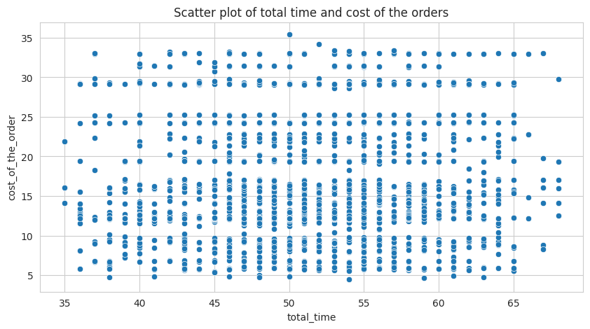

```python
# Lets check the relationship betwee the total time and the cost of the order
plt.figure(figsize=(10,5))
plt.title("Scatter plot of total time and cost of the orders")
sns.scatterplot(data=df,x='total_time',y='cost_of_the_order')
plt.show()
```

```python
df[["total_time",'cost_of_the_order']].corr()
```

|  | total_time | cost_of_the_order |
| --- | --- | --- |
| total_time | 1.000 | 0.006 |
| cost_of_the_order | 0.006 | 1.000 |

.From the scatter plt and the correlatio coeficient which equaI to 0.006, it seems there is no relation between the total time (the food has to prepare and the deliver time) and the cost of the orders.

#### Rating and Cost of the order

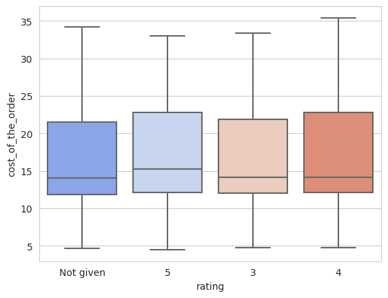

```python
sns.boxplot(data=df,x='rating',y='cost_of_the_order',palette='coolwarm')
plt.show()
```

.There are no significant difference between the cost of the orders in the rating levels. The median of the cost of the order is around 15 dollars. The minimum cost in the four levels is 5 dollars and the maximum are around to 35 dollars

#### Rating and total time

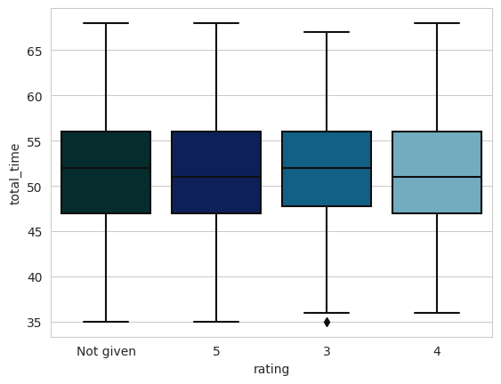

```python
sns.boxplot(data=df,x='rating',y='total_time',palette='ocean')
plt.show()
```

There are no significant difference between the total time in the rating levels. The median of the cost of the order is around 50 min.There is a slightly minumim outlier in rating 3.

#### Cuisine type and Rating

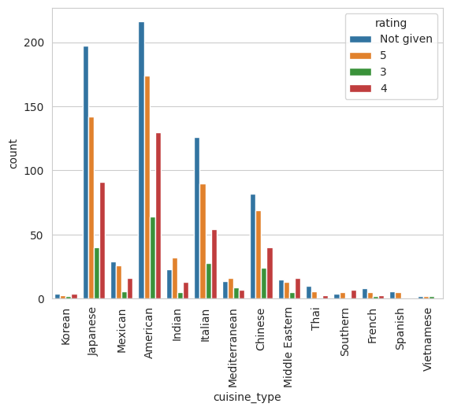

```python
sns.countplot(data=df,x='cuisine_type',hue='rating')
plt.xticks(rotation =90)
plt.show()
```

.The top highest rating cuisine are American, Japanese, and Italian.

.The least rating cuisine are Vetnamese.

.About 200 orders did not get rating in the American and the Japanese cuisine.

#### Cuisine type and cost of the order

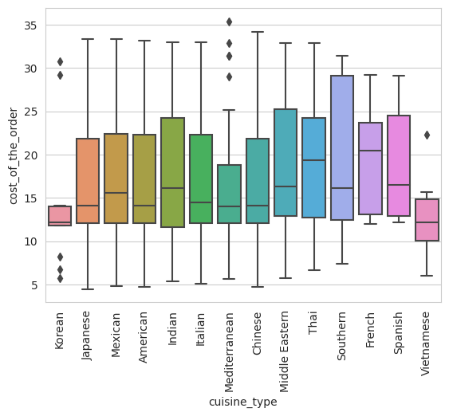

```python
sns.boxplot(data=df,x='cuisine_type',y='cost_of_the_order')
plt.xticks(rotation=90)
plt.show()
```

. The minimum cost of the most cuisine around 5 dollars except French, Spanish and Korean cuisine.

.There are lower and upper outliers in the korean cuisine.

.The cost of the American and the Italian cuisine arounds 5 dollars to less than 35 dollars with median 14 dollars.

. The cost of the Mediteranean cuisine is between 5 to 25 dollars with maximum outlier reach 35 dollars

.The median cost of the Vietnamese cuisine is about 12 dollars with 23 dollars as an outlier.

#### Cuisine type and food preparation time

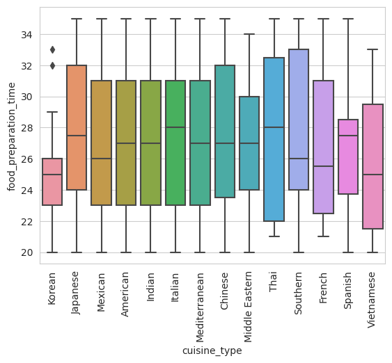

```python
sns.boxplot(data=df,x='cuisine_type',y='food_preparation_time')
plt.xticks(rotation=90)
plt.show()
```

.The minumum time to prepare food in each cusine is 20min except for Thai and French cuisine the minimum time is about 21.

.The Korean cuisine has the lowest prepare time which range from 20 min to 29min with some outlier reach thirties.

#### Number of resturant in each cuisine

```python
#count the number of resturants in each cuisine
count = df.groupby(['cuisine_type','restaurant_name']).size().reset_index().groupby('cuisine_type').size()
count
```

```
cuisine_type
American          41
Chinese           16
French             3
Indian            14
Italian           31
Japanese          29
Korean             5
Mediterranean      5
Mexican           11
Middle Eastern     7
Southern           2
Spanish            3
Thai               9
Vietnamese         3
dtype: int64
```

###### Obeservation

.The American cuisine has the largest number of resturants which is 41 resturants then the Italian with 31 resturant and The Japanese with 29 resturants.The Chines cuisine with 16 resturants.

#### Day of the week and Cost of the order

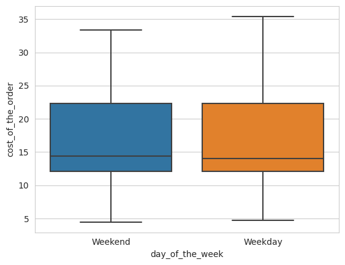

```python
sns.boxplot(data=df,x='day_of_the_week',y='cost_of_the_order')
plt.show()
```

#### Day of the week and Delivery time

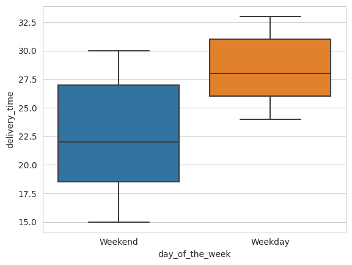

```python
sns.boxplot(data=df,x='day_of_the_week',y='delivery_time')
plt.show()
```

. The median of delivery time during the weekends is 22min with minimum 15 min and maximum 30 min.

### **Question 13:** The company wants to provide a promotional offer in the advertisement of the restaurants. The condition to get the offer is that the restaurants must have a rating count of more than 50 and the average rating should be greater than 4. Find the restaurants fulfilling the criteria to get the promotional offer. [3 marks]

```python
# changing the data type to int
df['rating'] = df['rating'].replace('Not given',0)
df['rating'] = df['rating'].astype(int)

df.head()
```

|  | order_id | customer_id | restaurant_name | cuisine_type | cost_of_the_order | day_of_the_week | rating | food_preparation_time | delivery_time | total_time |
| --- | --- | --- | --- | --- | --- | --- | --- | --- | --- | --- |
| 0 | 1477147 | 337525 | Hangawi | Korean | 30.750 | Weekend | 0 | 25 | 20 | 45 |
| 1 | 1477685 | 358141 | Blue Ribbon Sushi Izakaya | Japanese | 12.080 | Weekend | 0 | 25 | 23 | 48 |
| 2 | 1477070 | 66393 | Cafe Habana | Mexican | 12.230 | Weekday | 5 | 23 | 28 | 51 |
| 3 | 1477334 | 106968 | Blue Ribbon Fried Chicken | American | 29.200 | Weekend | 3 | 25 | 15 | 40 |
| 4 | 1478249 | 76942 | Dirty Bird to Go | American | 11.590 | Weekday | 4 | 25 | 24 | 49 |

```python
#Filter the restaurant's column for those restaurants that do not have a rating as 'Not given'
offer = df[['restaurant_name','rating']]
offer = offer.loc[offer['rating'] > 0]
offer = offer.reset_index(drop=True)
offer
```

|  | restaurant_name | rating |
| --- | --- | --- |
| 0 | Cafe Habana | 5 |
| 1 | Blue Ribbon Fried Chicken | 3 |
| 2 | Dirty Bird to Go | 4 |
| 3 | Tamarind TriBeCa | 3 |
| 4 | Barbounia | 3 |
| ... | ... | ... |
| 1157 | RedFarm Broadway | 3 |
| 1158 | TAO | 5 |
| 1159 | Chipotle Mexican Grill $1.99 Delivery | 5 |
| 1160 | The Smile | 5 |
| 1161 | Jack's Wife Freda | 5 |

1162 rows × 2 columns

```python
#Create a dataframe that contains the restaurant names with their rating counts
discount = offer['restaurant_name'].value_counts()
discount = discount.reset_index()
discount.rename(columns ={"index": "restaurant_name", "restaurant_name": "count"},inplace = True)
discount
```

|  | restaurant_name | count |
| --- | --- | --- |
| 0 | Shake Shack | 133 |
| 1 | The Meatball Shop | 84 |
| 2 | Blue Ribbon Sushi | 73 |
| 3 | Blue Ribbon Fried Chicken | 64 |
| 4 | RedFarm Broadway | 41 |
| ... | ... | ... |
| 151 | Philippe Chow | 1 |
| 152 | Dirty Bird To Go (archived) | 1 |
| 153 | The MasalaWala | 1 |
| 154 | Kambi Ramen House | 1 |
| 155 | 'wichcraft | 1 |

156 rows × 2 columns

```python
#Get all the restaurant names that have a rating count of more than 50 with their rating
discount = pd.merge(discount,offer,how='inner')
discount
```

|  | restaurant_name | count | rating |
| --- | --- | --- | --- |
| 0 | Shake Shack | 133 | 5 |
| 1 | Shake Shack | 133 | 5 |
| 2 | Shake Shack | 133 | 5 |
| 3 | Shake Shack | 133 | 5 |
| 4 | Shake Shack | 133 | 4 |
| ... | ... | ... | ... |
| 1157 | Philippe Chow | 1 | 5 |
| 1158 | Dirty Bird To Go (archived) | 1 | 4 |
| 1159 | The MasalaWala | 1 | 4 |
| 1160 | Kambi Ramen House | 1 | 5 |
| 1161 | 'wichcraft | 1 | 5 |

1162 rows × 3 columns

```python
#find the mean rating of the restaurants by using the groupby function
discount = discount[(discount["count"] > 50)]
discount.groupby(discount['restaurant_name']).rating.mean()
```

```
restaurant_name
Blue Ribbon Fried Chicken   4.328
Blue Ribbon Sushi           4.219
Shake Shack                 4.278
The Meatball Shop           4.512
Name: rating, dtype: float64
```

#### Observations:

The restaurants fulfilling the criteria to get the promotional offer are:

Blue Ribbon Fried Chicken 4.328

Blue Ribbon Sushi 4.219

Shake Shack 4.278

The Meatball Shop 4.512

### **Question 14:** The company charges the restaurant 25% on the orders having cost greater than 20 dollars and 15% on the orders having cost greater than 5 dollars. Find the net revenue generated by the company across all orders. [3 marks]

```python
#calculate the revenue of the orders according to the coditions
df["revenue"] = 0
df.loc[df['cost_of_the_order'] > 20, "revenue"] = 0.25 * df['cost_of_the_order']
df.loc[df['cost_of_the_order'] > 5,"revenue"] = 0.15 * df['cost_of_the_order']
df.head()
```

|  | order_id | customer_id | restaurant_name | cuisine_type | cost_of_the_order | day_of_the_week | rating | food_preparation_time | delivery_time | total_time | revenue |
| --- | --- | --- | --- | --- | --- | --- | --- | --- | --- | --- | --- |
| 0 | 1477147 | 337525 | Hangawi | Korean | 30.750 | Weekend | 0 | 25 | 20 | 45 | 4.612 |
| 1 | 1477685 | 358141 | Blue Ribbon Sushi Izakaya | Japanese | 12.080 | Weekend | 0 | 25 | 23 | 48 | 1.812 |
| 2 | 1477070 | 66393 | Cafe Habana | Mexican | 12.230 | Weekday | 5 | 23 | 28 | 51 | 1.835 |
| 3 | 1477334 | 106968 | Blue Ribbon Fried Chicken | American | 29.200 | Weekend | 3 | 25 | 15 | 40 | 4.380 |
| 4 | 1478249 | 76942 | Dirty Bird to Go | American | 11.590 | Weekday | 4 | 25 | 24 | 49 | 1.738 |

```python
#The sum of the revenue across all orders
df['revenue'].sum()
```

[output not shown]

### **Question 15:** The company wants to analyze the total time required to deliver the food. What percentage of orders take more than 60 minutes to get delivered from the time the order is placed? (The food has to be prepared and then delivered.) [2 marks]

```python
#Calculating the precentage of orders take more than 60 min of total time (prepare + deliver)
order = df.loc[df['total_time'] > 60].shape[0]
print("The percentage of orders take more than 60 minutes to get delivered from the time the order is placed",'%.2f'%((order/df.shape[0]*100)),'%')
```

```
The percentage of orders take more than 60 minutes to get delivered from the time the order is placed 10.54 %
```

### **Question 16:** The company wants to analyze the delivery time of the orders on weekdays and weekends. How does the mean delivery time vary during weekdays and weekends? [2 marks]

```python
df.groupby(df["day_of_the_week"]).delivery_time.mean()
```

```
day_of_the_week
Weekday   28.340
Weekend   22.470
Name: delivery_time, dtype: float64
```

#### Observations:

.The mean delivery time during weekdays is 28.34 min and 22.47 min in weekends

### Recommendations:

- The app should find a way to decrease the not given rate of the orders.
- The top popular cuisines have the largets numbers of resturants in the app, We recommed to increase the number of resturants options in the less popular cuisines such as the Vietnamese cuisine.
- There company may need to improve the delivary time during the weekdays.
- The company need to encourage the customers to try the least common cusine such as the Vetnamese and the Korean.